# 仓储物流岗位招聘和薪酬

## 总述

本次采集有效数据7380元(城市发布量>=100),主要分析物流和仓储相关岗位招聘和薪酬，岗位如：仓管员、仓库主管、海运/空运/货代操作、物料员、单证员、客服、调度员等。我们将从如下方面分析：

- 01.城市分布：招聘需求主要集中在上海、深圳、广州，分别占市场需求的19%、17%、14%，平均月薪分别为8000元、7740元、6199元；其余城市均在6%及以下。
- 02.行业分布：交通/运输/物流占17%，平均月薪8496元；机械/设备/重工占9%，平均月薪6280元。
- 03.公司规模：<1000人企业占89%，平均月薪6785元；1000-5000人占8%，平均月薪7752元。
- 04.公司类型：民企占74%，平均月薪6715元；外企占13%，平均月薪7666元。
- 05.工作经验：5年以下占93%，平均月薪6543元；5-10年占6%，平均月薪11521元。
- 06.学历要求：中学学历占43%，平均月薪5735元；大专占46%，平均月薪7419元。

## 01.城市分布

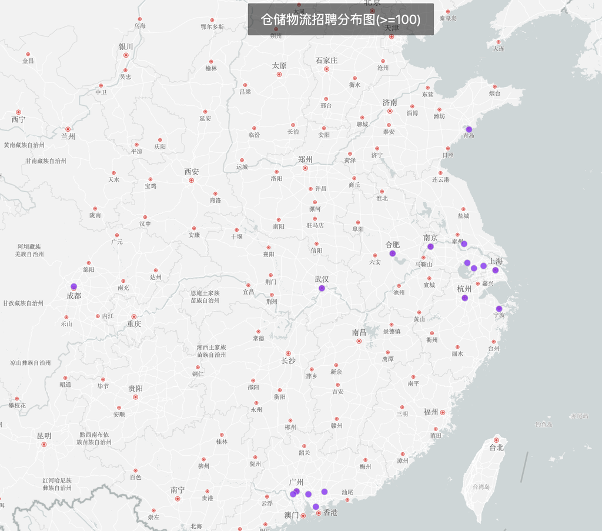

roadmap

## 02.行业分布

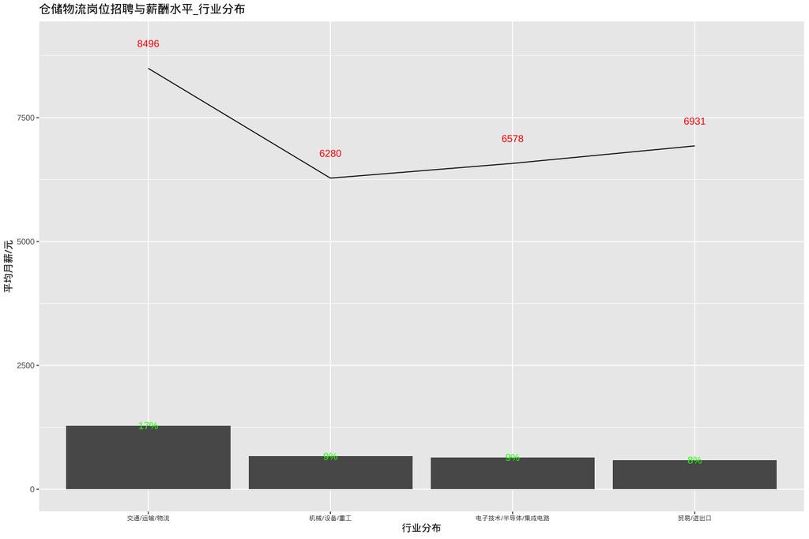

industries

## 03.公司规模

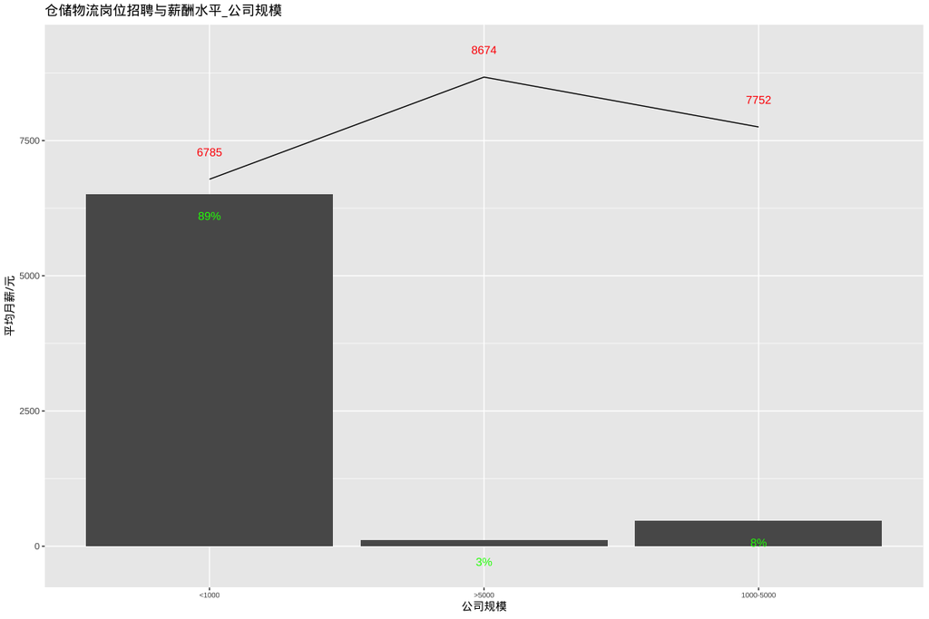

com_size

## 04.公司类型

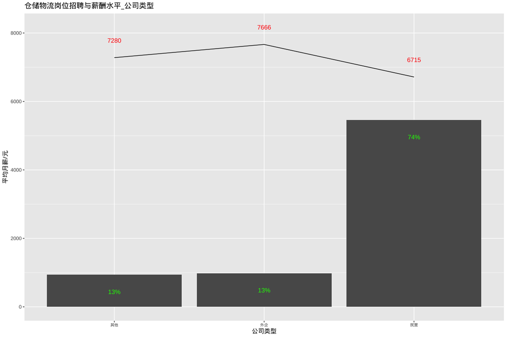

com_type

## 05.工作经验

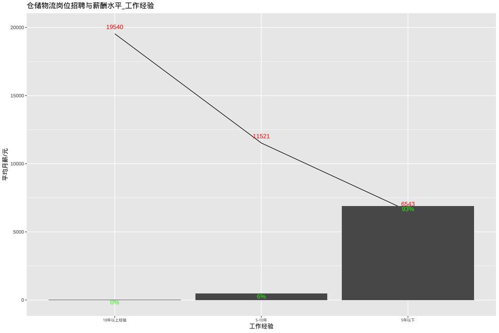

experience

## 06.学历要求

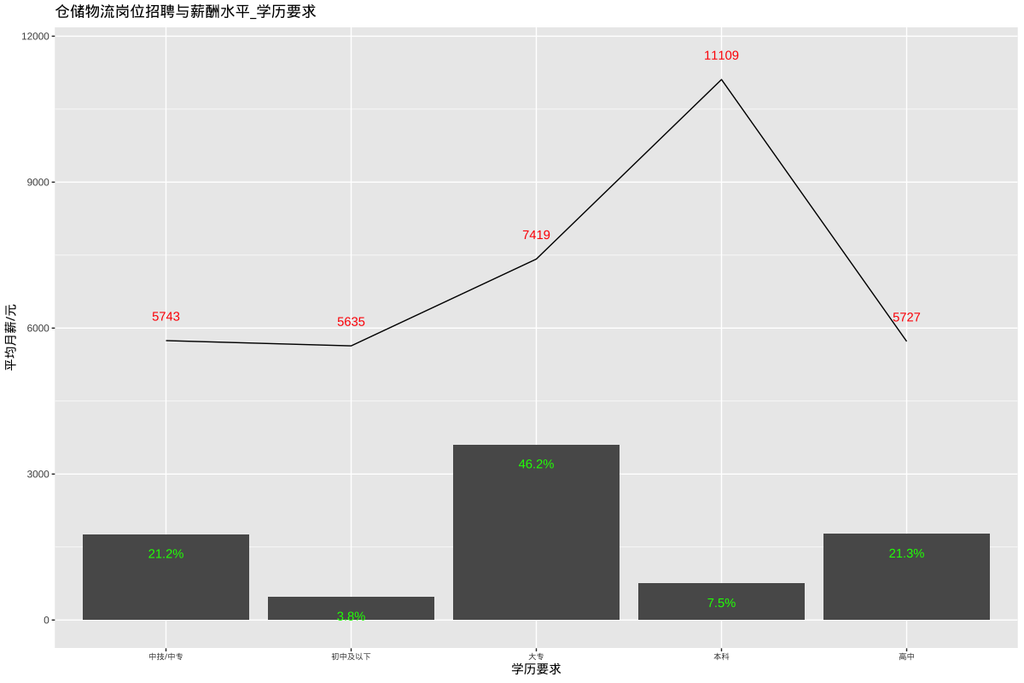

education